# HW3

Business Analytics and Data Mining

Zachary Palmore

3/26/2021

## Overview

In this homework assignment, we will explore, analyze and model a data set containing information on crime for various neighborhoods of a major city. Each record has a response variable indicating whether or not the crime rate is above the median crime rate (1) or not (0).

Our objective is to build a binary logistic regression model on the training data set to predict whether the neighborhood will be at risk for high crime levels. We will provide classifications and probabilities for the evaluation data set using our binary logistic regression model. We can only use the variables given to us (or variables that are derived from the variables provided).

## Introduction

```r
# Packages
library(tidyverse)
library(kableExtra)
library(Amelia)
library(caret)
library(pROC)
# Data
cdata <- read.csv("https://raw.githubusercontent.com/palmorezm/msds/main/621/HW3/crime-training-data_modified.csv")
cdata.eval <- read.csv("https://raw.githubusercontent.com/palmorezm/msds/main/621/HW3/crime-evaluation-data_modified.csv")
```

There are 466 observations in this data set with 13 different variables. Each observation is a statistical summary that indicates an attribute associated with a particular neighborhood within the major city. For example the first variable ‘zn’ contains the proportion of residential land zoned for lots that are over 25000 square feet. The first five observations of each variable are shown.

```r
first5.tbl <- cdata[1:5,]
first5.tbl %>%
  kbl() %>%
  kable_styling()
```

| zn | indus | chas | nox | rm | age | dis | rad | tax | ptratio | lstat | medv | target |
| --- | --- | --- | --- | --- | --- | --- | --- | --- | --- | --- | --- | --- |
| 0 | 19.58 | 0 | 0.605 | 7.929 | 96.2 | 2.0459 | 5 | 403 | 14.7 | 3.70 | 50.0 | 1 |
| 0 | 19.58 | 1 | 0.871 | 5.403 | 100.0 | 1.3216 | 5 | 403 | 14.7 | 26.82 | 13.4 | 1 |
| 0 | 18.10 | 0 | 0.740 | 6.485 | 100.0 | 1.9784 | 24 | 666 | 20.2 | 18.85 | 15.4 | 1 |
| 30 | 4.93 | 0 | 0.428 | 6.393 | 7.8 | 7.0355 | 6 | 300 | 16.6 | 5.19 | 23.7 | 0 |
| 0 | 2.46 | 0 | 0.488 | 7.155 | 92.2 | 2.7006 | 3 | 193 | 17.8 | 4.82 | 37.9 | 0 |

```r
vardesc <- data.frame(matrix(c(
'zn',   'proportion of residential land zoned for large lots (over 25000 square feet)',
'indus',    'proportion of non-retail business acres per suburb',
'chas', 'a dummy var. for whether the suburb borders the Charles River (1) or not (0)',
'nox',  'nitrogen oxides concentration (parts per 10 million)',
'rm',   'average number of rooms per dwelling',
'age',  'proportion of owner-occupied units built prior to 1940',
'dis',  'weighted mean of distances to five Boston employment centers',
'rad', 'index of accessibility to radial highways',
'tax',  'full-value property-tax rate per $10,000',
'ptratio',  'pupil-teacher ratio by town',
'lstat',    'lower status of the population (percent)',
'medv', 'median value of owner-occupied homes in $1000s',
'target',   'whether the crime rate is above the median crime rate (1) or not (0)'), byrow = TRUE, ncol = 2))
colnames(vardesc) <- c('Variable', 'Description')
kable(vardesc) %>%
  kable_styling()
```

| Variable | Description |
| --- | --- |
| zn | proportion of residential land zoned for large lots (over 25000 square feet) |
| indus | proportion of non-retail business acres per suburb |
| chas | a dummy var. for whether the suburb borders the Charles River (1) or not (0) |
| nox | nitrogen oxides concentration (parts per 10 million) |
| rm | average number of rooms per dwelling |
| age | proportion of owner-occupied units built prior to 1940 |
| dis | weighted mean of distances to five Boston employment centers |
| rad | index of accessibility to radial highways |
| tax | full-value property-tax rate per $10,000 |
| ptratio | pupil-teacher ratio by town |
| lstat | lower status of the population (percent) |
| medv | median value of owner-occupied homes in $1000s |
| target | whether the crime rate is above the median crime rate (1) or not (0) |

## Data Exploration

Describe the size and the variables in the crime training data set. Consider that too much detail will cause a manager to lose interest while too little detail will make the manager consider that you aren’t doing your job. Some suggestions are given below. Please do NOT treat this as a check list of things to do to complete the assignment. You should have your own thoughts on what to tell the boss. These are just ideas. a. Mean / Standard Deviation / Median b. Bar Chart or Box Plot of the data c. Is the data correlated to the target variable (or to other variables?) d. Are any of the variables missing and need to be imputed “fixed”?

Checking to see if any of the data are missing.

```r
sum(is.na(cdata))
```

```
## [1] 0
```

None of the data are missing.

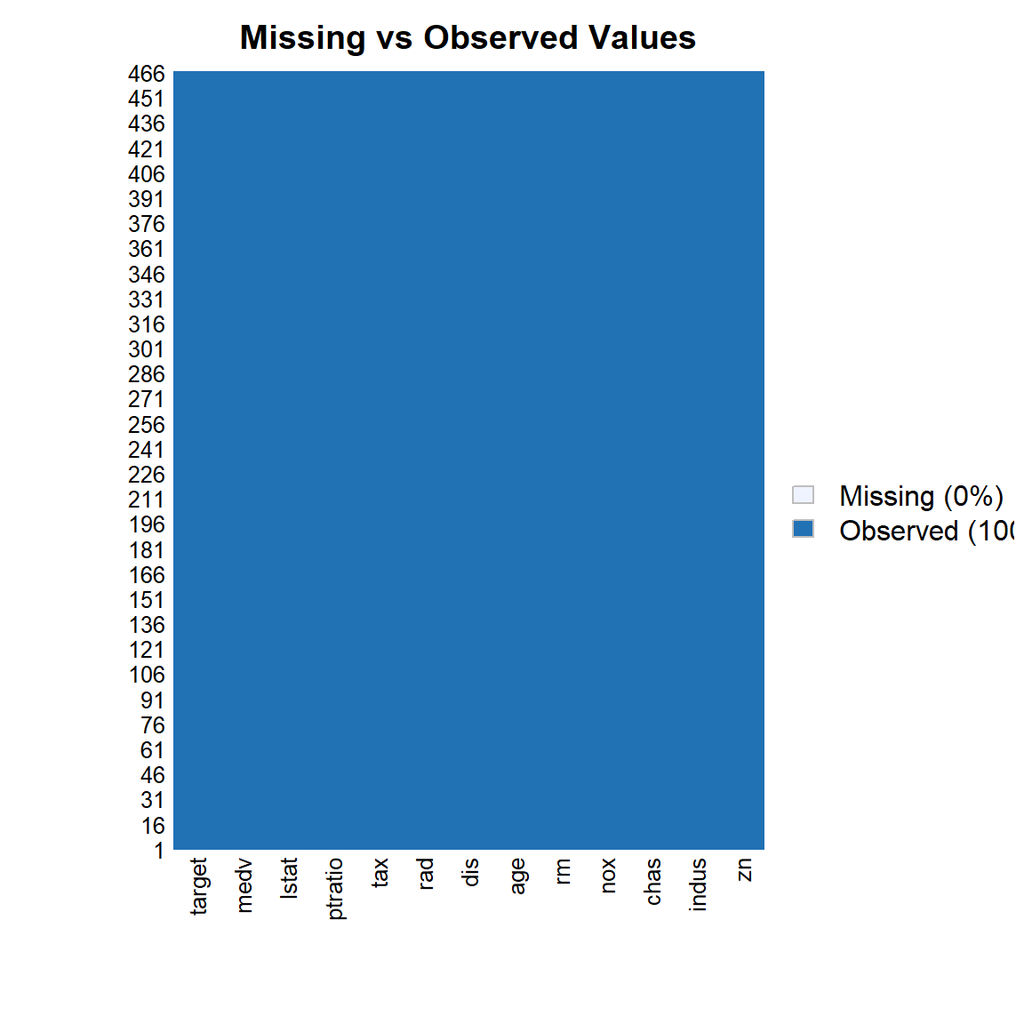

```r
missmap(cdata, main = "Missing vs Observed Values")
```

```r
summary.tbl <- summary(cdata)
summary.tbl %>%
  kable %>%
  kable_styling()
```

|  | zn | indus | chas | nox | rm | age | dis | rad | tax | ptratio | lstat | medv | target |
| --- | --- | --- | --- | --- | --- | --- | --- | --- | --- | --- | --- | --- | --- |
|  | Min. : 0.00 | Min. : 0.460 | Min. :0.00000 | Min. :0.3890 | Min. :3.863 | Min. : 2.90 | Min. : 1.130 | Min. : 1.00 | Min. :187.0 | Min. :12.6 | Min. : 1.730 | Min. : 5.00 | Min. :0.0000 |
|  | 1st Qu.: 0.00 | 1st Qu.: 5.145 | 1st Qu.:0.00000 | 1st Qu.:0.4480 | 1st Qu.:5.887 | 1st Qu.: 43.88 | 1st Qu.: 2.101 | 1st Qu.: 4.00 | 1st Qu.:281.0 | 1st Qu.:16.9 | 1st Qu.: 7.043 | 1st Qu.:17.02 | 1st Qu.:0.0000 |
|  | Median : 0.00 | Median : 9.690 | Median :0.00000 | Median :0.5380 | Median :6.210 | Median : 77.15 | Median : 3.191 | Median : 5.00 | Median :334.5 | Median :18.9 | Median :11.350 | Median :21.20 | Median :0.0000 |
|  | Mean : 11.58 | Mean :11.105 | Mean :0.07082 | Mean :0.5543 | Mean :6.291 | Mean : 68.37 | Mean : 3.796 | Mean : 9.53 | Mean :409.5 | Mean :18.4 | Mean :12.631 | Mean :22.59 | Mean :0.4914 |
|  | 3rd Qu.: 16.25 | 3rd Qu.:18.100 | 3rd Qu.:0.00000 | 3rd Qu.:0.6240 | 3rd Qu.:6.630 | 3rd Qu.: 94.10 | 3rd Qu.: 5.215 | 3rd Qu.:24.00 | 3rd Qu.:666.0 | 3rd Qu.:20.2 | 3rd Qu.:16.930 | 3rd Qu.:25.00 | 3rd Qu.:1.0000 |
|  | Max. :100.00 | Max. :27.740 | Max. :1.00000 | Max. :0.8710 | Max. :8.780 | Max. :100.00 | Max. :12.127 | Max. :24.00 | Max. :711.0 | Max. :22.0 | Max. :37.970 | Max. :50.00 | Max. :1.0000 |

```r
set.seed(72747)
indecies <- createDataPartition(cdata$target, p = .7, list = FALSE, times = 1)
train <- cdata[indecies,]
test <- cdata[-indecies,]
```

```r
train %>%
  select(-target) %>%
  summary() %>%
  kable() %>%
  kable_styling()
```

|  | zn | indus | chas | nox | rm | age | dis | rad | tax | ptratio | lstat | medv |
| --- | --- | --- | --- | --- | --- | --- | --- | --- | --- | --- | --- | --- |
|  | Min. : 0.00 | Min. : 0.46 | Min. :0.00000 | Min. :0.3920 | Min. :3.863 | Min. : 2.90 | Min. : 1.174 | Min. : 1.000 | Min. :188.0 | Min. :12.60 | Min. : 1.92 | Min. : 5.00 |
|  | 1st Qu.: 0.00 | 1st Qu.: 5.19 | 1st Qu.:0.00000 | 1st Qu.:0.4480 | 1st Qu.:5.878 | 1st Qu.: 43.10 | 1st Qu.: 2.105 | 1st Qu.: 4.000 | 1st Qu.:281.0 | 1st Qu.:16.90 | 1st Qu.: 7.06 | 1st Qu.:16.80 |
|  | Median : 0.00 | Median : 9.69 | Median :0.00000 | Median :0.5380 | Median :6.226 | Median : 77.30 | Median : 3.132 | Median : 5.000 | Median :335.0 | Median :18.90 | Median :11.74 | Median :21.00 |
|  | Mean : 10.45 | Mean :11.15 | Mean :0.06422 | Mean :0.5536 | Mean :6.303 | Mean : 68.44 | Mean : 3.762 | Mean : 9.153 | Mean :406.2 | Mean :18.38 | Mean :12.66 | Mean :22.37 |
|  | 3rd Qu.: 12.50 | 3rd Qu.:18.10 | 3rd Qu.:0.00000 | 3rd Qu.:0.6240 | 3rd Qu.:6.638 | 3rd Qu.: 93.95 | 3rd Qu.: 5.117 | 3rd Qu.: 8.000 | 3rd Qu.:666.0 | 3rd Qu.:20.20 | 3rd Qu.:16.56 | 3rd Qu.:24.80 |
|  | Max. :100.00 | Max. :27.74 | Max. :1.00000 | Max. :0.8710 | Max. :8.725 | Max. :100.00 | Max. :10.710 | Max. :24.000 | Max. :711.0 | Max. :22.00 | Max. :36.98 | Max. :50.00 |

## Data Preparation

Describe how you have transformed the data by changing the original variables or creating new variables. If you did transform the data or create new variables, discuss why you did this. Here are some possible transformations. a. Fix missing values (maybe with a Mean or Median value) b. Create flags to suggest if a variable was missing c. Transform data by putting it into buckets d. Mathematical transforms such as log or square root (or use Box-Cox) e. Combine variables (such as ratios or adding or multiplying) to create new variables

## Build Models

Using the training data, build at least three different binary logistic regression models, using different variables (or the same variables with different transformations). You may select the variables manually, use an approach such as Forward or Stepwise, use a different approach, or use a combination of techniques. Describe the techniques you used. If you manually selected a variable for inclusion into the model or exclusion into the model, indicate why this was done. Be sure to explain how you can make inferences from the model, as well as discuss other relevant model output. Discuss the coefficients in the models, do they make sense? Are you keeping the model even though it is counter intuitive? Why? The boss needs to know.

## Select Models

Decide on the criteria for selecting the best binary logistic regression model. Will you select models with slightly worse performance if it makes more sense or is more parsimonious? Discuss why you selected your models. For the binary logistic regression model, will you use a metric such as log likelihood, AIC, ROC curve, etc.? Using the training data set, evaluate the binary logistic regression model based on (a) accuracy, (b) classification error rate, (c) precision, (d) sensitivity, (e) specificity, (f) F1 score, (g) AUC, and (h) confusion matrix. Make predictions using the evaluation data set